# Bioconductor stats

Lluís Revilla

Sun Dec 31 22:47:32 2017

# 1 Introduction

Bioconductor provide [stats of the project](https://www.bioconductor.org/packages/stats/). If you are curious about what is the evolution of the downloads of a certain package or how does the downloads progress with time this is the right place.

Bioconductor classifies the packages in three categories:

- Software
- [Experimental data](http://bioconductor.org/packages/release/BiocViews.html#___AnnotationData)
- [Annotation](http://bioconductor.org/packages/release/BiocViews.html#___ExperimentData)

For each category a page with the stats of the packages of each category is provided, together with a file:

- [Software stats](http://bioconductor.org/packages/stats/)
- [Experimental data stats](http://bioconductor.org/packages/stats/data-experiment.html)
- [Annotation stats](http://bioconductor.org/packages/stats/data-annotation.html)

The project also has a [support site](http://support.bioconductor.org) which has an api to access the data. We will access analyze it too. We first join the stats of the downloads and IPs of the packages to work easier and compare between them.

```r
web <- "https://www.bioconductor.org/packages/stats/" # Base url
colClasses <- c("factor", "character", "character", "numeric", "numeric")
software <- read.delim(paste0(web, "bioc/bioc_pkg_stats.tab"),
                    colClasses = colClasses)
experimental <- read.delim(paste0(web, "data-experiment/experiment_pkg_stats.tab"),
                    colClasses = colClasses)
annotation <- read.delim(paste0(web, "data-annotation/annotation_pkg_stats.tab"),
                    colClasses = colClasses)
# Convert to data.tables
setDT(software)
setDT(experimental)
setDT(annotation)
# Assing Category
software[, Category := "Software"]
experimental[, Category := "Experimental"]
annotation[, Category := "Annotation"]
# Bind
stats <- rbind(software, experimental, annotation)
yearly <- stats[Month == "all", ]
stats <- stats[Month != "all", , ]
stats[, .(Packages = length(unique(Package))), by = Category]
```

```
##        Category Packages
## 1:     Software     1930
## 2: Experimental      728
## 3:   Annotation     2586
```

However, there are some packages are erroniously classified in several categories. You can see it if we calculate the overlap between packages:

```r
packages <- list(Software = unique(software$Package),
                 Experimental = unique(experimental$Package),
                 Annotation = unique(annotation$Package))
f <- function(x, y){
  length(intersect(x, y))
}
vf <- Vectorize(f)
outer(packages, packages, vf)
```

```
##              Software Experimental Annotation
## Software         1930          471         27
## Experimental      471          728         17
## Annotation         27           17       2586
```

We need to classify better, we will use the total number of downloads to put them in a single category based in the total downloads for each category:

```r
# Calculates number of downloads per package and category
max_cat <- stats[, .(Total = sum(Nb_of_downloads)), by = c("Package", "Category")]
# Select the category with max downloads per package
max_cat <- max_cat[, .(Category = Category[which.max(Total)]), by = Package]
# Join by name
stats <- stats[max_cat, , on = "Package"]
yearly <- yearly[max_cat, on = "Package"]
# Substitute name
stats <- stats[, -"Category"]
names(stats)[names(stats) == "i.Category"] <- "Category"

yearly <- yearly[Category == i.Category, ]
yearly <- yearly[, -"i.Category"]
stats[, .(Packages = length(unique(Package))), by = Category]
```

```
##        Category Packages
## 1:     Software     1812
## 2: Experimental      351
## 3:   Annotation     2574
```

# 2 Initial exploratory analysis

We do a little visual exploration of the total downloads per category:

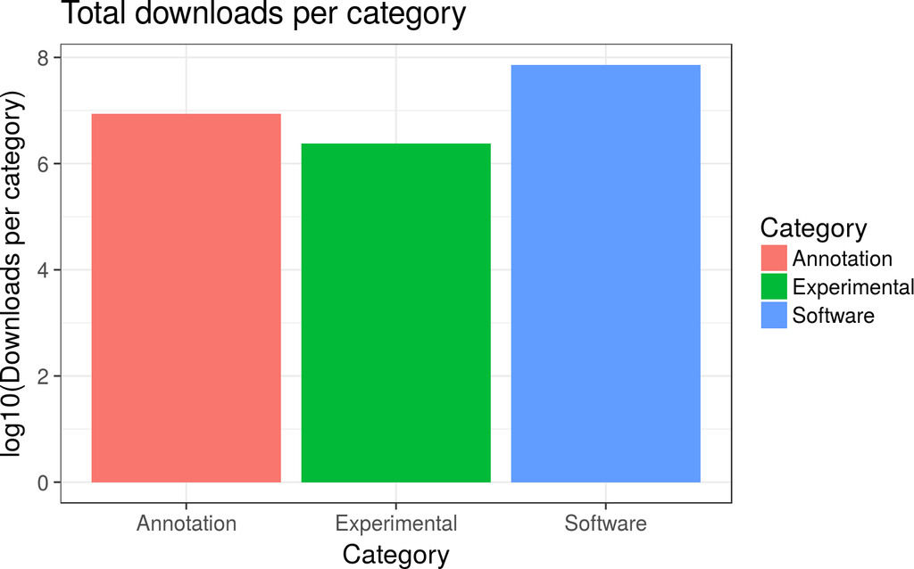

Figure 1: Total downloads per Category

```r
theme_bw <- theme_bw(base_size = 16)
p <- ggplot(stats[ , .(Downloads = sum(Nb_of_downloads)), by = c("Category")]) +
  geom_bar(aes(Category, log10(Downloads), fill = Category), stat = "identity") +
  theme_bw +
  ylab("log10(Downloads per category)") +
  ggtitle("Total downloads per category")
print(p)
```

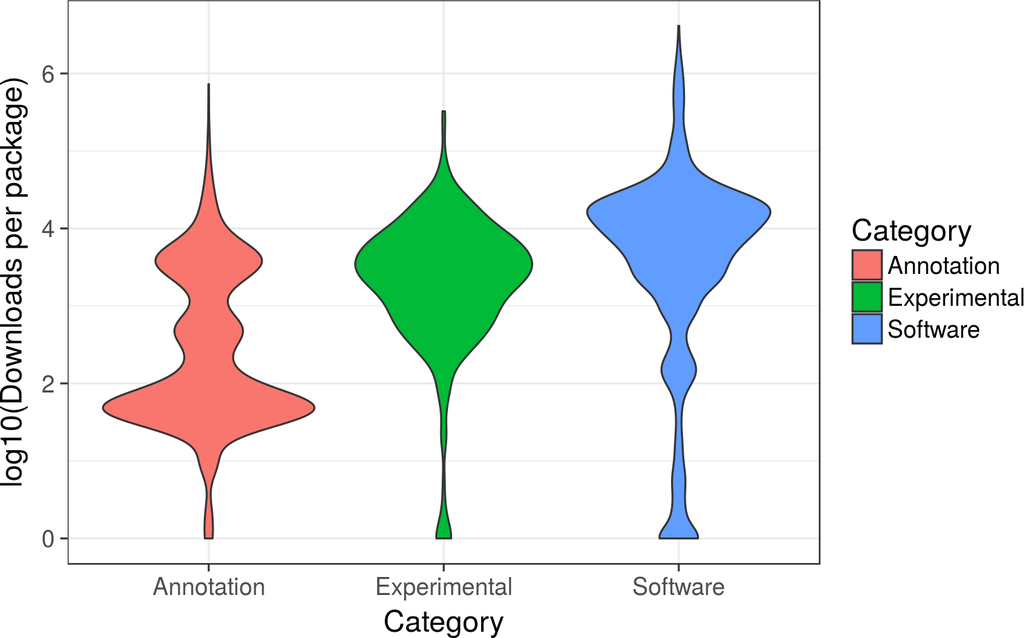

```r
p <- ggplot(stats[ , .(Downloads = log10(sum(Nb_of_downloads))), by = c("Package", "Category")]) +
  geom_violin(aes(Category, Downloads, fill = Category)) +
  theme_bw +
  ylab("log10(Downloads per package)")
print(p)
```

To work more easily, we convert the months to a date:

```r
monthsConvert <- function(x) {
  if (x == "Jan") {
    "01"
  } else if (x == "Feb"){
    "02"
  } else if (x == "Mar"){
    "03"
  } else if (x == "Apr"){
    "04"
  } else if (x == "May"){
    "05"
  } else if (x == "Jun"){
    "06"
  } else if (x == "Jul"){
    "07"
  } else if (x == "Aug"){
    "08"
  } else if (x == "Sep"){
    "09"
  } else if (x == "Oct"){
    "10"
  } else if (x == "Nov"){
    "11"
  } else if (x == "Dec"){
    "12"
  }
}
stats$Month <- sapply(stats$Month, monthsConvert)
stats$Date <- as.POSIXct(as.yearmon(paste(stats$Year, stats$Month, sep = "-")), frac = 1)
bioc_packages <- c("BiocInstaller", "Biobase", "BiocGenerics", "S4Vectors", "IRanges", "AnnotationDbi")
stats <- stats[Nb_of_downloads != 0, ] # We remove rows of packages without a download in that month.
# Convert the data from several categories to one entry in the right category
stats <- stats[, .(Month = unique(Month), Year = unique(Year),
                   Category = unique(Category),
                   Nb_of_distinct_IPs = sum(Nb_of_distinct_IPs),
                  Nb_of_downloads = sum(Nb_of_downloads)) ,
               by = c("Package", "Date")]
save(stats, yearly, bioc_packages, monthsConvert, file="stats.RData")
```

We have also stored the data for future uses.

We can observe the number of packages downloaded for each category along time:

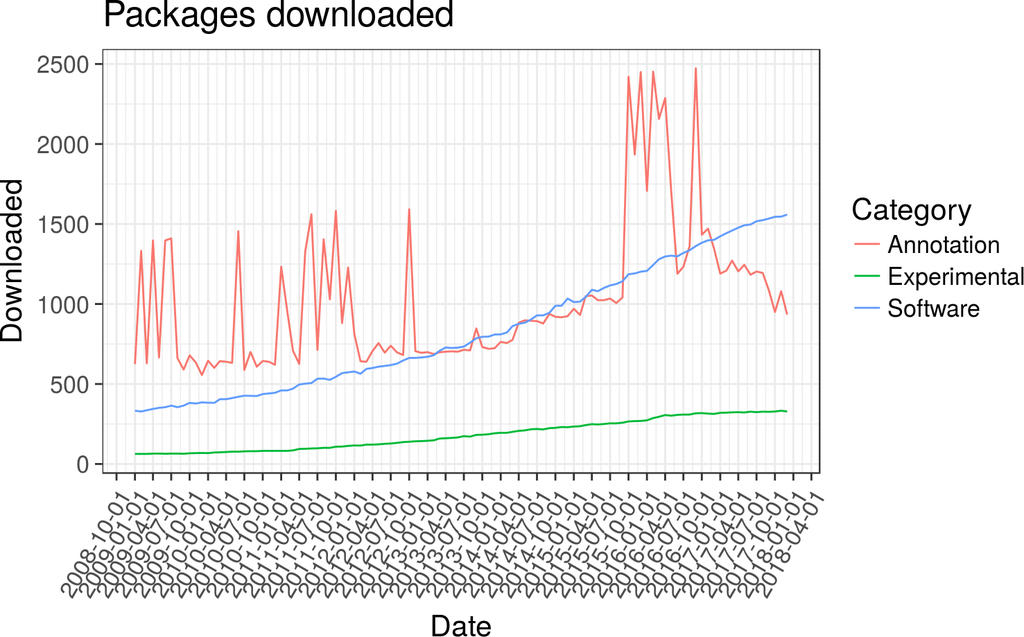

Figure 3: Packages downloaded per date and category  
For each category the number of packages downloaded are displayed

```r
theme <- theme(axis.text.x = element_text(angle = 60, hjust = 1))
scal <- scale_x_datetime(date_breaks = "3 months")
p <- ggplot(stats[,  .(Downloaded = .N), by = c("Date", "Category")], aes(Date, Downloaded, color = Category)) +
  geom_line() +
  theme_bw +
  ggtitle("Packages downloaded") +
  theme +
  scal
print(p)
```

We can see that the number of packages downloaded increase consistently for Software packages and at a slower peace also for Experimental data, but the Annnotations show some peaks. This peaks might be new databases added as a package in Bioconductor.

The number of download per month for each category:

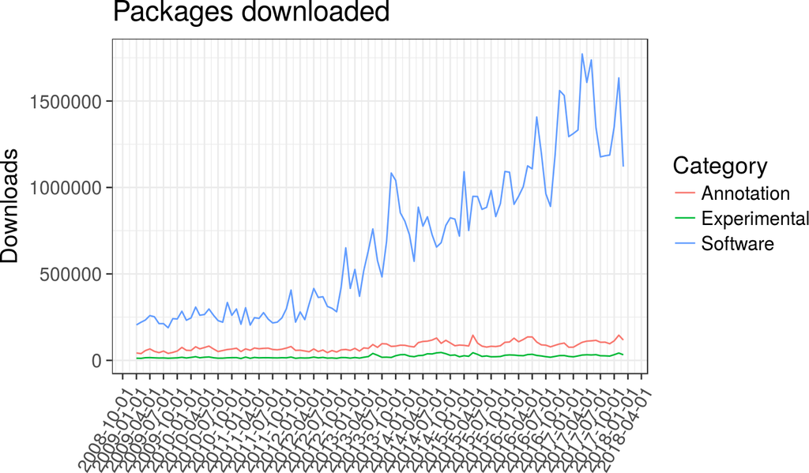

Figure 4: Downloads per date and category  
For each category the downloads are displayed

```r
p <- ggplot(stats[, .(Downloads = sum(Nb_of_downloads)), by = c("Date", "Category")], aes(Date, Downloads, color = Category)) +
  geom_line() +
  theme_bw +
  ggtitle("Packages downloaded") +
  xlab("") +
  theme +
  scal
print(p)
```

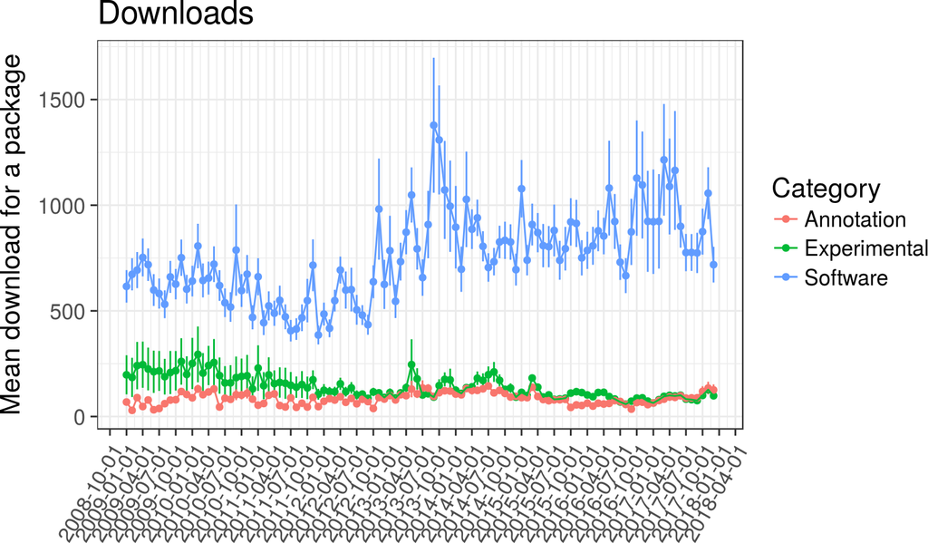

Figure 5: Downloads per package  
Mean of the downloads per package per category, the error bar is the standard error of the mean.

```r
pd <- position_dodge(0.1)
p <- ggplot(stats[, .(Number = mean(Nb_of_downloads),
                  sem = sd(Nb_of_downloads)/sqrt(.N)),
              by = c("Date", "Category")],
       aes(Date, Number, color = Category)) +
  geom_errorbar(aes(ymin = Number-sem, ymax = Number + sem),
                width = .1, position = pd) +
  geom_point() +
  geom_line() +
  theme_bw +
  ggtitle("Downloads") +
  ylab("Mean download for a package") +
  xlab("") +
  theme +
  scal
print(p)
```

Looking at the number of downloads per package along time it contradicts our hypothesis that competence for downloads in the Software package has increased. There is now more variation but the mean number of downloads per package remains more constant.  
We can see that for Annotation package the mean download per packages is the same from 2009. Experimental packages had much larger variation, but nowadays fewer experimental packages are used as we can see from the error bars. In software packages there is much larger variation since two years, but traditionally it had more variation and higher downloads per package than any other category.

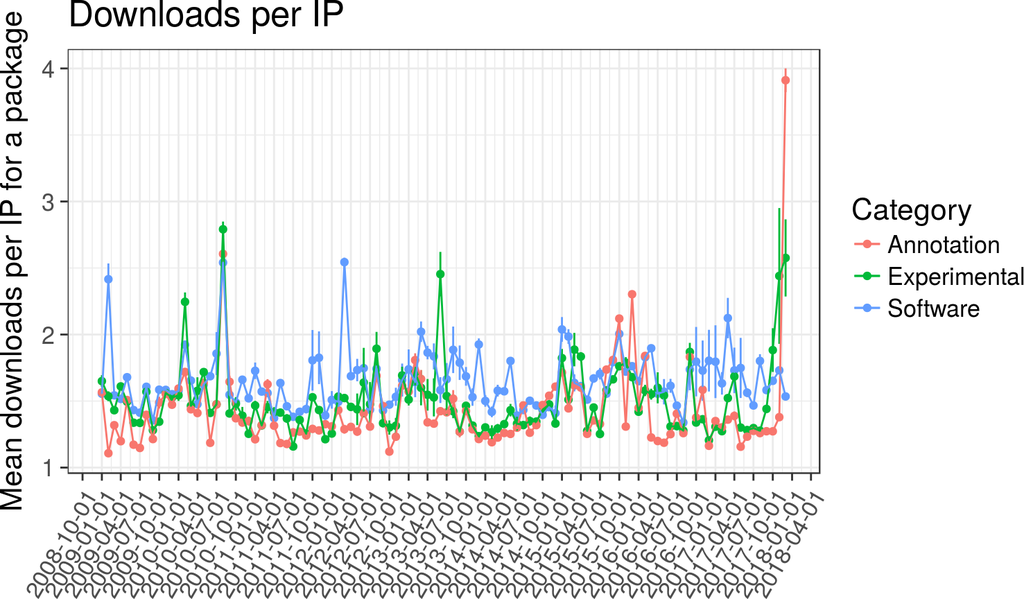

Figure 6: Downloads per IP  
Mean of the downloads per IP per package, the error bars are the standard error of the mean.

```r
p <- ggplot(stats[, .(Number = mean(Nb_of_downloads/Nb_of_distinct_IPs),
                 sem = sd(Nb_of_downloads/Nb_of_distinct_IPs)/sqrt(.N)),
              by = c("Date", "Category")],
       aes(Date, Number, color = Category)) +
  geom_point() +
  geom_errorbar(aes(ymin = Number - sem, ymax = Number + sem),
                width = .1, position = pd) +
  geom_line() +
  theme_bw +
  ggtitle("Downloads per IP") +
  ylab("Mean downloads per IP for a package") +
  xlab("") +
  theme +
  scal
print(p)
```

We can see that in some months there is an increase of downloads per IP in all the three categories whil other months the categories don’t follow the same pattern. In general the downloads per IP are around 1.5 to 2.

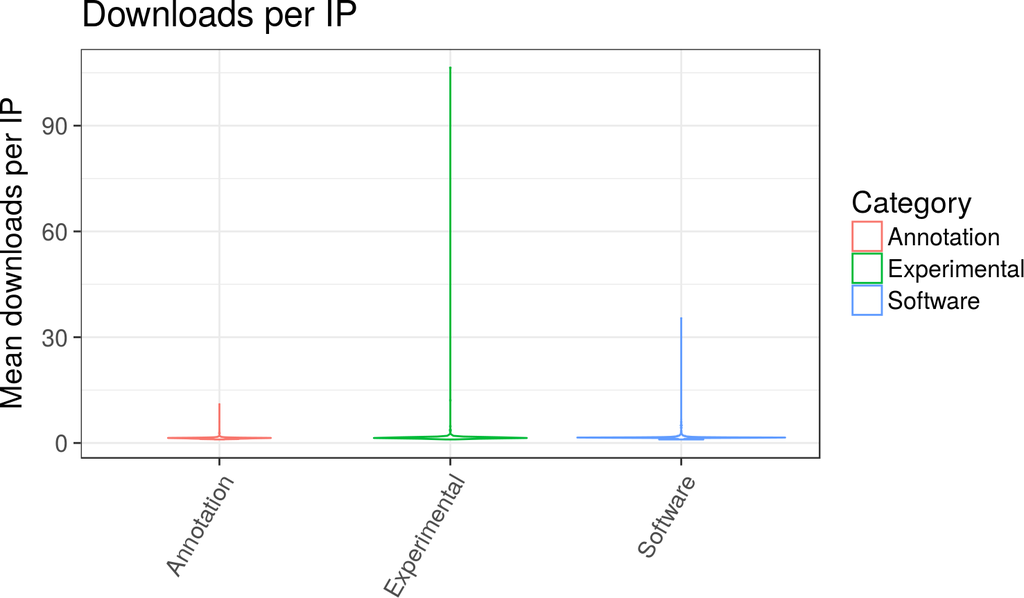

```r
p <- ggplot(stats[, .(Number = mean(Nb_of_downloads/Nb_of_distinct_IPs)),
              by = c("Package", "Category")],
       aes(Category, Number, color = Category)) +
  geom_violin() +
  theme_bw +
  ggtitle("Downloads per IP") +
  ylab("Mean downloads per IP") +
  xlab("") +
  theme
print(p)
```

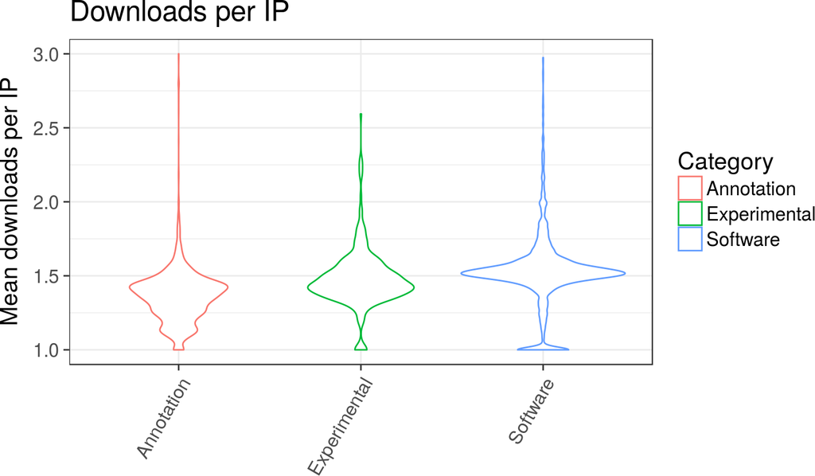

```r
p <- ggplot(stats[, .(Number = mean(Nb_of_downloads/Nb_of_distinct_IPs)),
              by = c("Package", "Category")],
       aes(Category, Number, color = Category)) +
  geom_violin() +
  theme_bw +
  ggtitle("Downloads per IP") +
  ylab("Mean downloads per IP") +
  xlab("") +
  theme +
  ylim(c(1, 3))
print(p)
```

Looking closer we can see that most of the packages are downloaded between 1 or twice per IP each month where the package is downloaded.

# 3 Updates

We can explore if the packages has been updated thorough the year by the same IP.

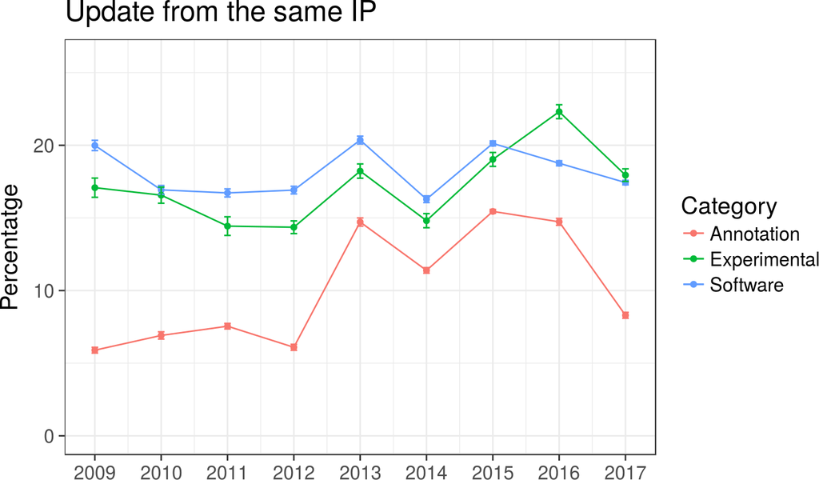

Figure 9: Package update  
Mean percentatge of the installation of the same package in a year by the same IP.

```r
staty <- stats[, .(Nb_of_distinct_IPs = sum(Nb_of_distinct_IPs)), by = c("Year", "Package", "Category")]
year <- staty[yearly, , on = c("Package", "Year")]
year[, Repeated_IP := Nb_of_distinct_IPs-i.Nb_of_distinct_IPs, by =  c("Year", "Package", "Category")]
year[, Repeated_IP_per := Repeated_IP/Nb_of_distinct_IPs*100, by =  c("Year", "Package", "Category")]
year2 <- year[, .(m = mean(Repeated_IP_per), sem = sd(Repeated_IP_per)/sqrt(.N)), by = c("Year", "Category")]
year2$Year <- as.numeric(year2$Year)
d <- date()
thisYear <- as.numeric(substr(d, nchar(d)-3, nchar(d)))
ggplot(year2, aes(Year, m, col = Category)) +
  geom_line() +
  geom_point() +
  geom_errorbar(aes(ymin = m - sem, ymax = m + sem),
                width = .1) +
  ylim(c(0, 26)) +
  ylab("Percentatge") +
  xlab("") +
  ggtitle("Update from the same IP") +
  theme_bw +
  scale_x_continuous(breaks = seq(2009, thisYear, 1))
```

Experimental and software packages tend to be updated around the 20% while annotation packages historically have been less updated from the same IP.

# 4 Analysis per category

For each category a similar analysis has been performed:

- Software analysis
- Experminetal data analysis
- Annotation analysis

# 5 Analysis support site

To analyse the support site relation with the packages we first downloaded and classify the data as described here.